# COVID-19: A Midwestern Reporting Project of WNIN and the University of Evansville

Minneapolis ZIP Code Analysis

Analysis performed by Maya Frederick, Timmy Miller, Ethan Morlock, Pearl Muensterman, and Darrin Weber, Ph.D.

## Background

The goal of this analysis is to find any connections, if they exist, between demographic data and the outbreak of COVID-19 in the city of Minneapolis. Demographic data was obtained from the Census Bureau through their 5-year American Community Survey published in 2018 (the most recent 5-year data available). COVID-19 case numbers were obtained from the Minnesota Department of Health. (https://www.health.state.mn.us/diseases/coronavirus/situation.html#map1).

**Conclusions** To start, we filtered the ZIP code 55450 out of the dataset because it was an outlier in every variable we analyzed that affected every test we ran on the data. This ZIP corresponds to non-residential area immediately around the Minneapolis-Saint Paul International Airport. The largest positive correlation with COVID case rate is with the proportion of Blacks and African Americans in a ZIP code (correlation of 0.784). This is followed by the proportion of families who make $30,000 or less a year and those families on public assistance at a correlation of 0.702. We then have people who have public insurance with a correlation of 0.663.

The other positive correlations we have are with non-U.S. citizens with a correlation of 0.611, public transportation with a correlation of 0.570, and lastly, essential workers with a correlation of 0.409. The biggest negative correlation is private health insurance at -0.816. Then families who make $100,000 or more a year is at -0.761.The last variable we have is the Gini index with a correlation of 0.059. The p-value of this correlation is so high that we can’t conclude there is any real difference from zero.

## Analysis

### COVID

[interactive chart not shown]

We see that COVID case rate is spread throughout Minneapolis, however ZIPs 55404 and 55454 do stand out as having a high case rate.

### Occupations (Essential vs. Non-essential)

Many “essential” workers tend to be towards the lower end of the income bracket. We look at whether there is a relationship between essential workers and contracting COVID.

The Census Bureau breaks workers into five categories: Management, business, science and arts; service; sales and office; natural resources, construction, and maintenance; and production, transportation, and material moving. Although these categories are undoubtedly not clear distinctions between essential and non-essential, we feel a good classification is to put natural resources, construction, and maintenance and production, transportation, material moving as essential and the other three categories as non-essential.

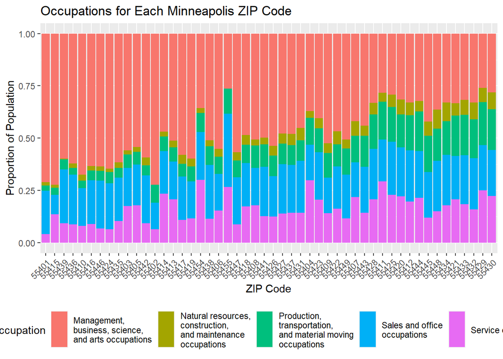

The proportion of the population that is considered “essential” is not particular high in any one ZIP code, ranging from 4% to 27.5% of the ZIP code’s population. The scatterplot below shows the relationship between essential jobs and COVID cases.

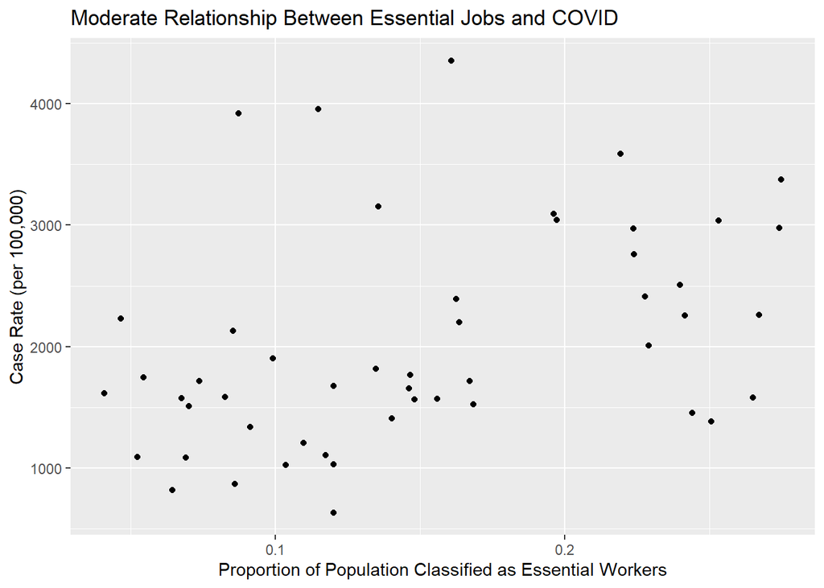

We see a pretty good spread with no clear outliers. When we test our correlation, we get a value of 0.409305 ($p=$ 0.003162). This tells us that there is a moderate correlation between the percentage of the population working “essential” jobs and the rate of COVID cases: as a ZIP code has more essential workers, it also has a higher COVID case rate.

### Citizenship

The Census Bureau provides a distinction between different types of U.S. citizenship (e.g., naturalization, born in U.S., born abroad, etc.). We focus on the simple distinction between being a U.S. citizen and not.

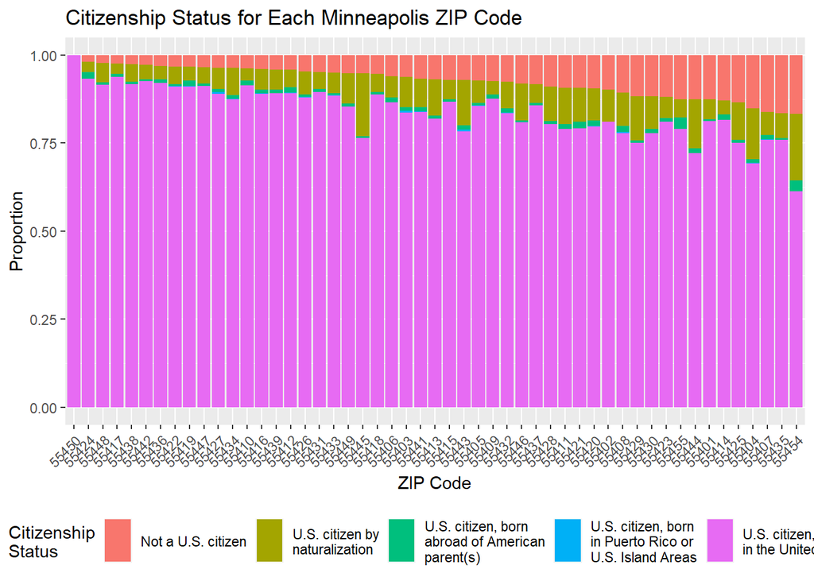

The range of citizenship is not too large, ranging from over 83% to 100%. The scatterplot below shows the relationship between the proportion of a ZIP code’s population not being a U.S. citizen and the COVID case rate.

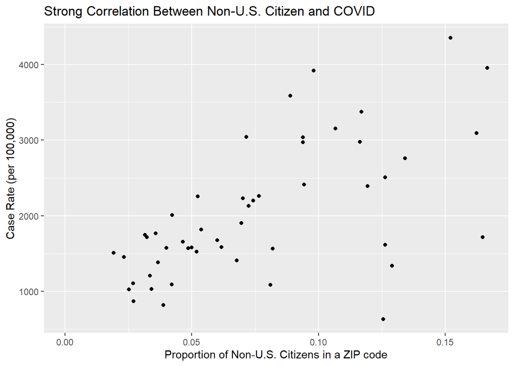

We don’t see any outlying ZIP codes and get a correlation value of 0.610552 ($p=$ 0.000002). This is a moderate-to-strong positive correlation, which means a ZIP code with a larger population of non-citizens is also showing a higher COVID case rate.

### Income

We look at the income data in increments designated by the Census Bureau. We calculated the proportion of people making over $100,000 to order the ZIP codes on the $x$-axis in the following graph.

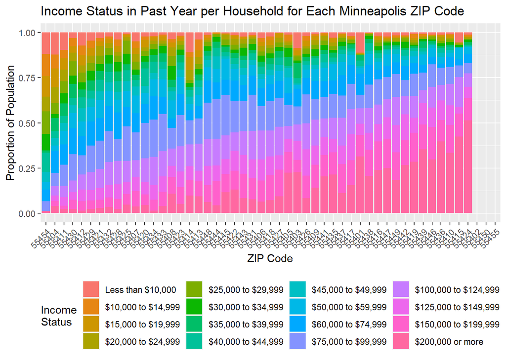

We see a nice distribution of six-figure incomes across the ZIP codes, ranging from just over 1% in ZIP 55454 all the way to over 77% of ZIP code 55424 making over $100,000.

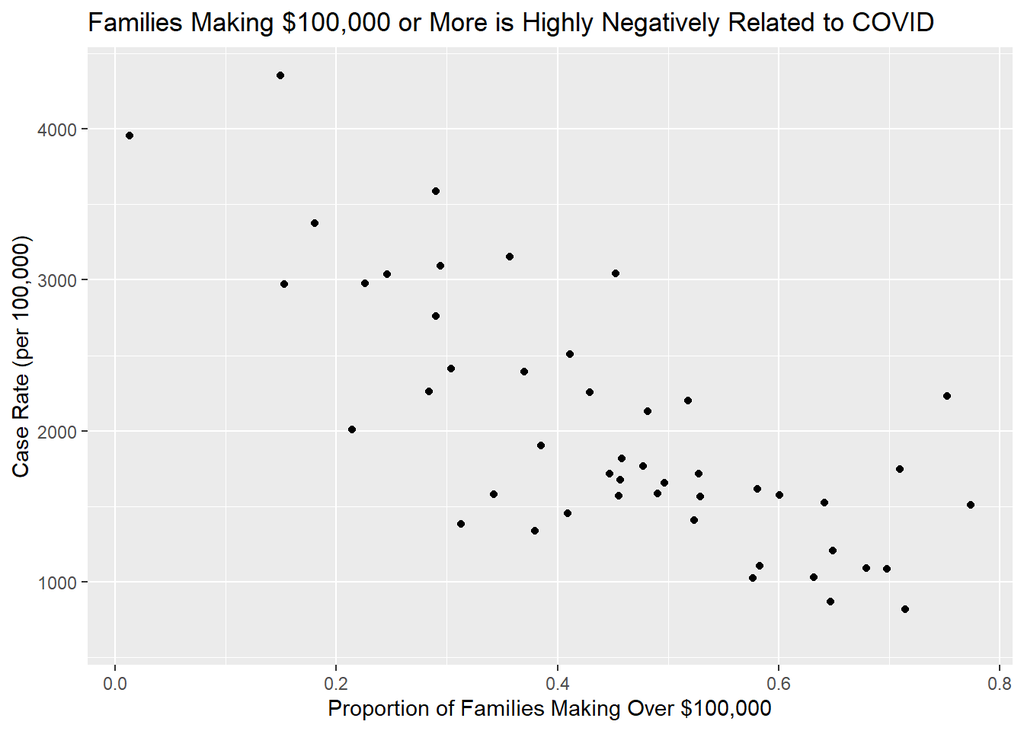

The correlation between a six-figure income and case rate is -0.760711 ($p\approx$ 0). This is a strong negative correlation. ZIP codes that are wealthier are highly correlated with having a smaller COVID case rate.

In the bar graph above showing the distribution of income levels for each ZIP code, we notice that the poorer incomes (making less than $30,000) does not necessarily follow the same distribution as the six-figure incomes. In other words, just because a ZIP code has a small proportion of six-figure incomes does not mean it has a high proportion of sub-$30,000 incomes. We see a few ZIP codes that deviate from this expected pattern. We look at examining the lower income brackets as a result.

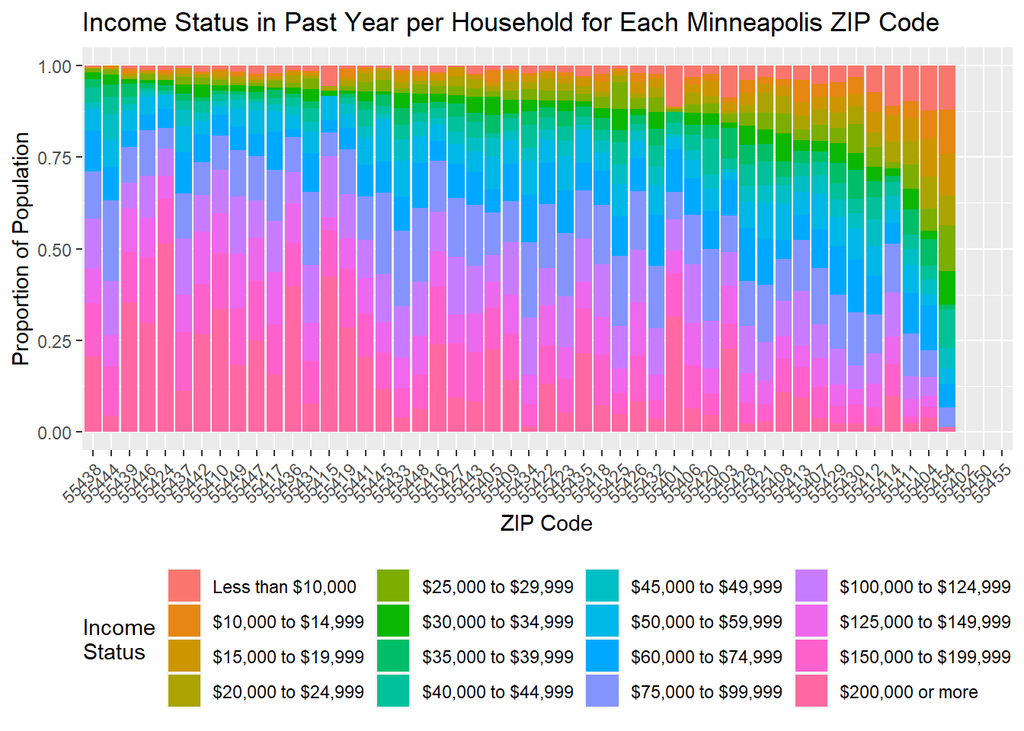

Once again, we see the fluctuation in the proportion of six-figure incomes, indicating that they don’t follow the same distribution as the sub-$30,000 incomes. We can look at the below scatterplot to investigate the relationship between sub-$30,000 incomes and the COVID case rate.

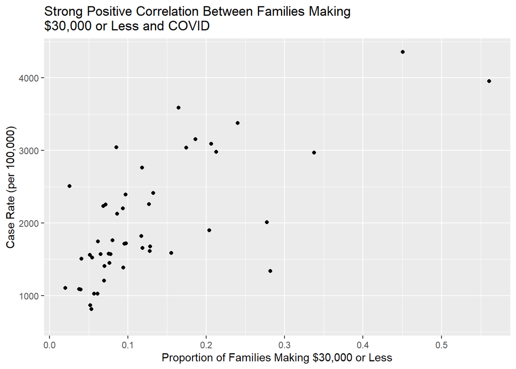

We see another strong correlation (0.702256 with $p\approx$ 0) between income and COVID. This reinforces our earlier findings that people making less money are much more likely to also get COVID at higher rates than people in ZIP codes with higher income brackets.

### Race

We’ve heard reports about minorities being hit harder by COVID. We look to see if the data supports that in Minneapolis.

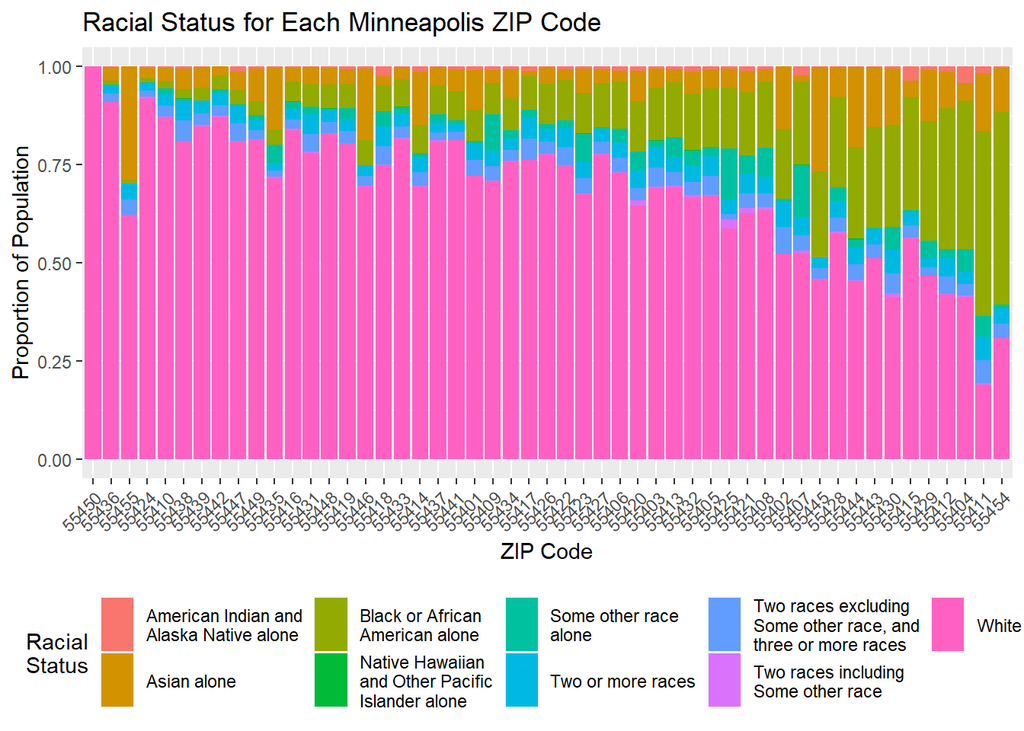

The proportions of “White alone” and “Black or African American alone” seem to be inversely related. This means looking at the “Black or African American alone” proportions within each ZIP code will yield a similar result as looking at “White alone.” One difference here may be with the “Asian alone” population. We see it as high as over 25% and it doesn’t follow the same distribution across ZIP codes as the white or Black populations.

We first focus on the relationship between the proportion Blacks and African Americans and COVID.

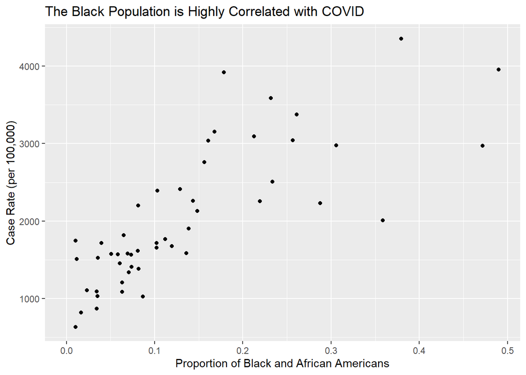

The correlation between the proportion of Black and African American within a ZIP code and case rate is 0.784414 ($p\approx$ 0). This is a strong positive correlation meaning African American communities are seeing a higher case rate of COVID in Minneapolis, confirming the trend we’re seeing at the national level.

We now look at the “Asian alone” population and perform a similar analysis.

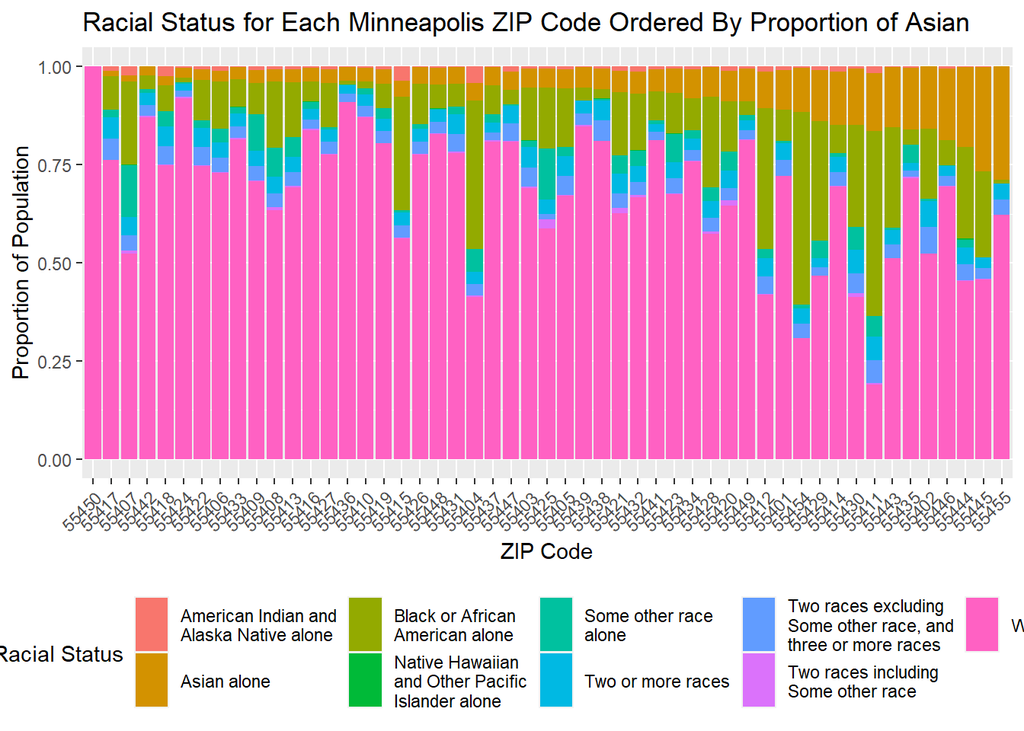

This graphic shows us that we do indeed see a different distribution of the Asian population when compared to Black and white populations.

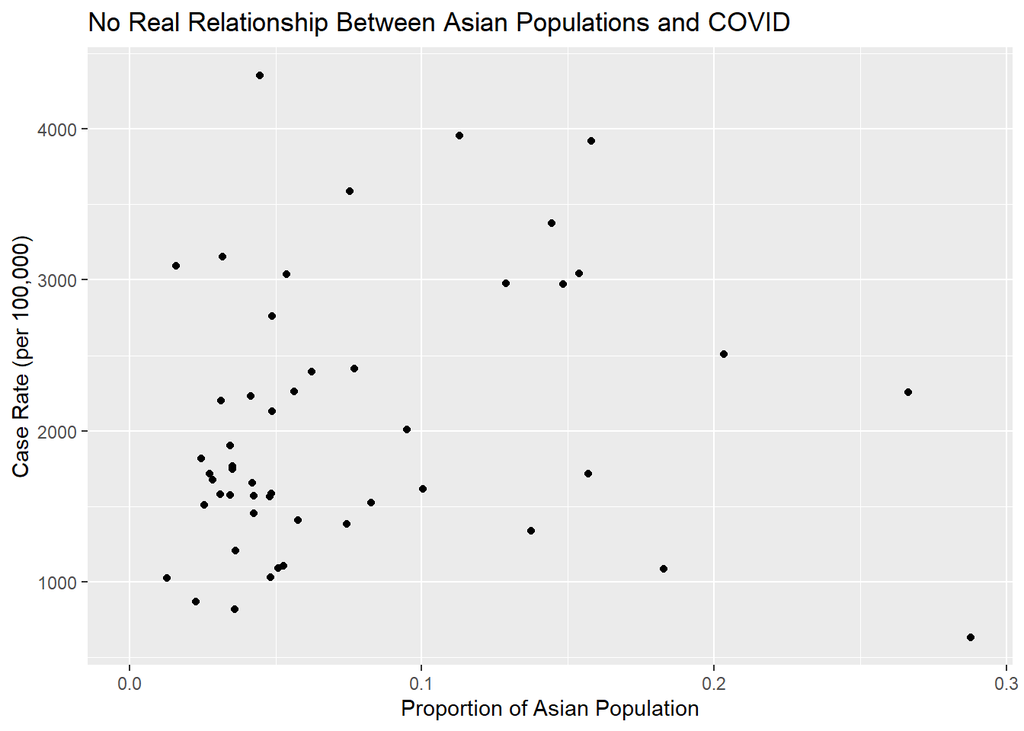

The scatterplot indicates that there is not a real correlation between the proportion of the Asian population within ZIP codes to that of COVID. Our correlation value is indistinguishable from 0 ($r=$ 0.140309 with $p=$ 0.331119).

### Gini Index

The Gini index is a measure of income inequality calculated by the Census Bureau using various different factors. The closer to 0 the Gini index, the more equally income is dispersed. A Gini index of 1 would indicate perfect inequality where a single group or individual collects all of the income.

The scatterplot shows the connection between Gini Index for Minneapolis ZIP codes and COVID.

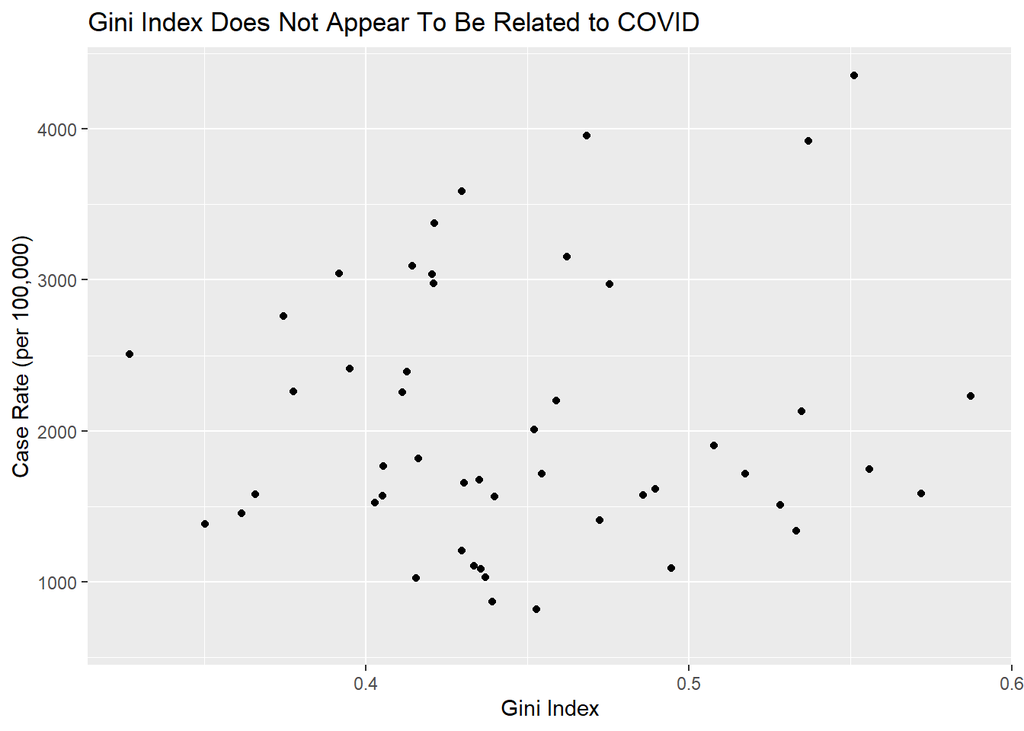

We see that no real pattern emerges between the Gini Index and COVID. This is supported by our correlation calculation that is statistically indistinguishable from 0 (0.05975 with $p=$ 0.683407).

### Insurance Coverage

Since access to private health insurance is not universal, we looked at the relationship between having some type of private health insurance and COVID as well as similarly looking at public health insurance. It is possible to have both public and private insurance, so these metrics are not mutually exclusive.

#### Private Health Insurance

We breakdown each ZIP code by the proportion of residents who have private health insurance.

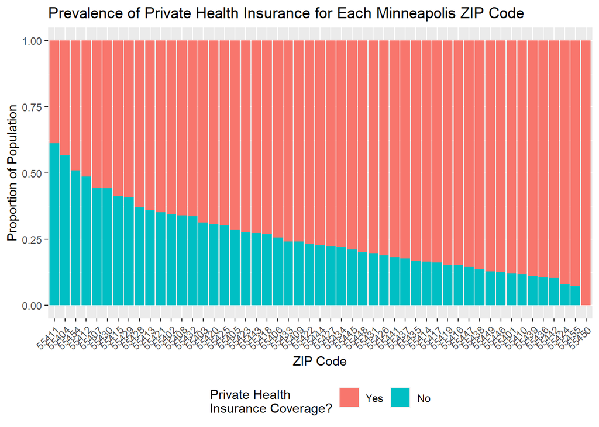

As we see, there is a wide range of those populations that have private health insurance, ranging from 100% of the population in 55450 to only 38.7% of the residents in 55411 having private health insurance. But how does this relate to COVID cases?

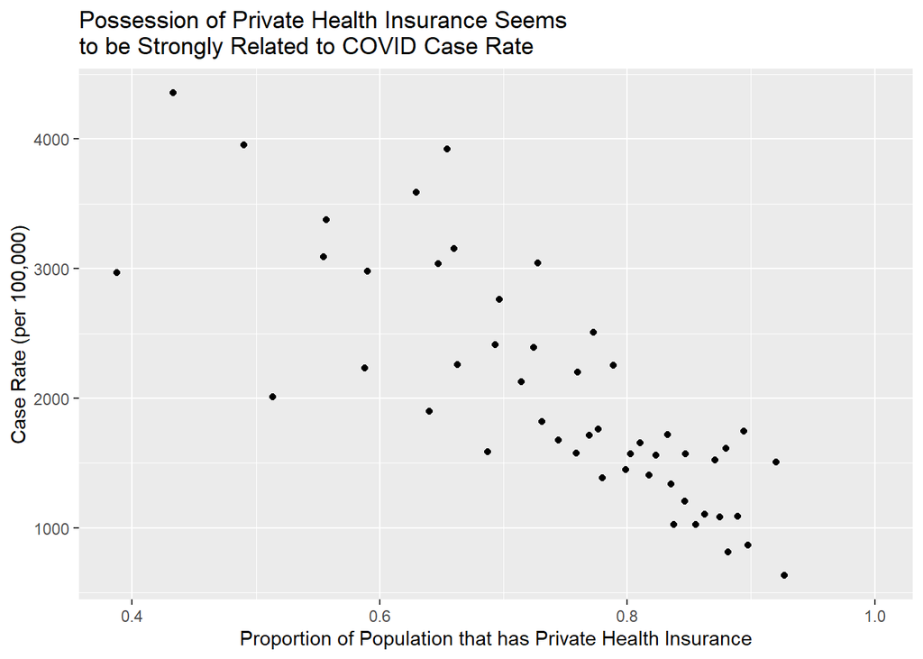

There seems to be an incredibly strong correlation. A test gives us a correlation of -0.816193 ($p\approx$ 0). We have strong evidence that there is a close connection between the proportion of the population that has private health insurance and the case rate for COVID. In this case, as the proportion that have private health insurance increases, we see a decrease in the case rate.

#### Public Health Insurance

We breakdown each ZIP code by the proportion of residents who have public health insurance.

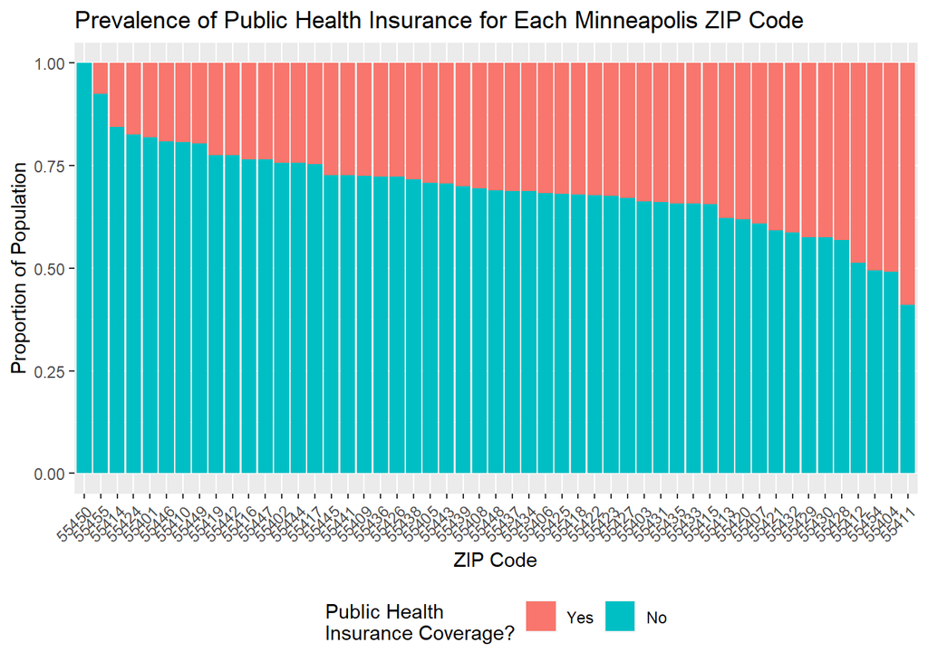

We still have a descent distinction between ZIP codes as to the proportion of their populations that have public insurance (ranges from 0% to almost 59%). We can look at how these proportions relate to COVID in the following plot.

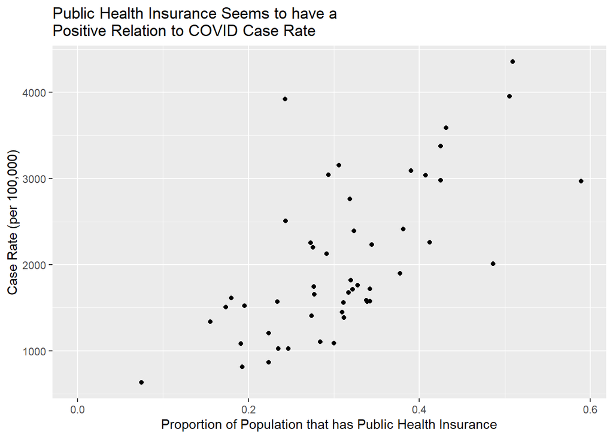

Again, we seem to have a strong relationship between possession of public health insurance and the case rate for COVID. Our correlation is 0.66365 ($p\approx$ 0). While this is a strong correlation, it is not as strong as with private health insurance. Nevertheless, as the proportion of the population within a ZIP code that has public health insurance increases, so does the case rate for COVID.

### Public Assistance Income

Another measure of income inequality might be the prevalence of public assistance income or food stamps within a ZIP code. We look at this demographic in connection to COVID.

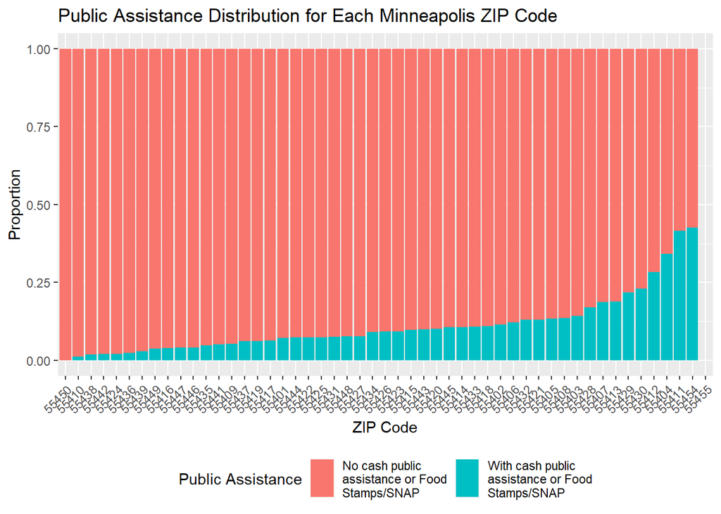

Our ZIP codes range from 0% of the population on public assistance all the way to nearly 43% of the ZIP code population on public assitance.

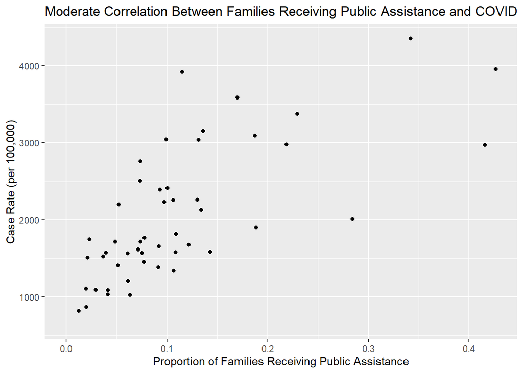

From here, we obtain a correlation value of 0.702244 ($p\approx$ 0). This is a strong positive correlation indicating that when the proportion of the ZIP code population on public assistance goes up, the case rate also goes up.

### Transportation to Work

The use of public transportation is more prevalent among lower incomes, while at the same time public transportation poses a higher risk of contracting COVID. We look to see if this idea plays out in the data for Minneapolis.

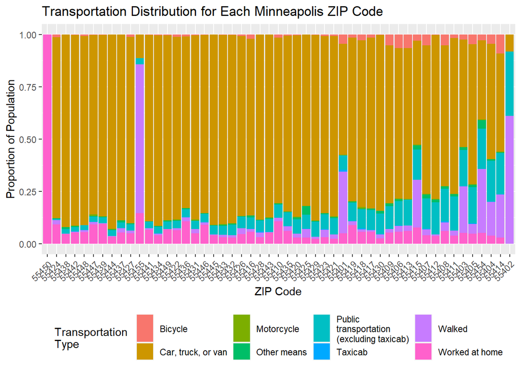

The percentage of the population that uses public transportation is not too high, never reaching above 31%. For our analysis, we grouped “Public transportation (excluding taxicab)” and “Taxicab” together to form our public use variable. Most Minneapolis residents provide their own motorized transportation, while in a few ZIP codes walking and working from home dominant the transportation field. It’s relationship to COVID can be seen in the following graph.

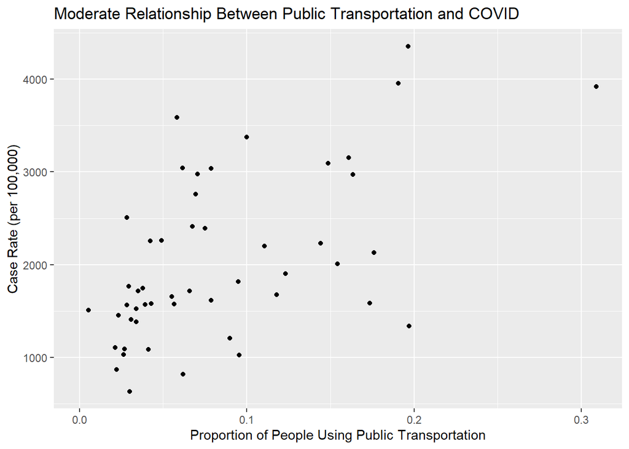

We see a moderate relationship between the use of public transportation and COVID. Conducting our tests gives us a correlation of 0.570235 ($p\approx$ 0). This is a moderate to strong correlation and indicates that as a ZIP code sees higher use of public transportation, it is also seeing a higher COVID rate.

### Age

We start with our basic graphic displaying the distribution of ages throughout the ZIP codes.

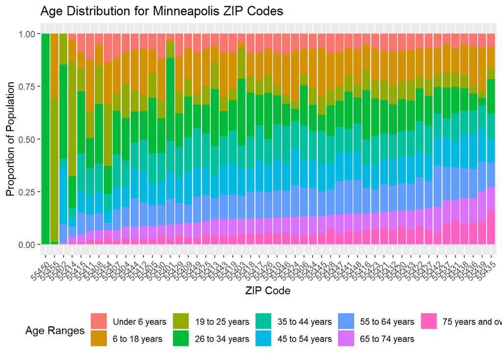

We focus on the relationship between COVID cases and the proportion of the population that is 65 years or older.

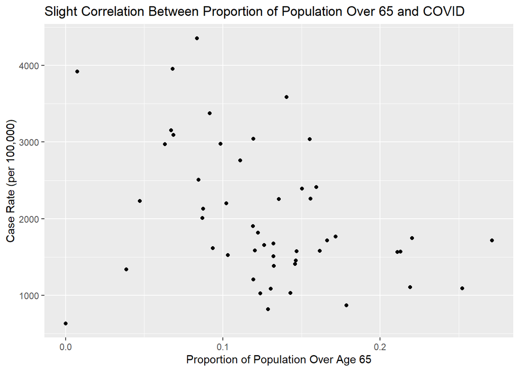

## Conclusions

In Minneapolis we looked at 9 different categories and analyzed 12 variables within them by ZIP code. We had to remove ZIP code 55450 because it was an outlier in every variable looked at, which affected the analysis of the other ZIP codes. 55450 has a very small population with a lot of cases so that explains why it was such a statistical outlier.

We had several variables with significant correlations. Private Health Insurance and income over $100,000 saw a negative relationship with COVID case rate (as one variable goes up, the other variable goes down). These were strong relationships, too. We also saw that public assistance, public health insurance, non-citizenship, and Black and African American populations saw a positive relationship with COVID. As the proportion of the population using of fitting in these categories went up, the COVID case rate also went up. Finally, we saw some weak or nonexistent relationships with age and Gini index, and only moderate relationships with public transportation and occupation.